# Научная презентация

Дисциплина:Операционные системы

Алехин Давид Андреевич

Российский университет дружбы народов, Москва, Россия

Математический институт имени Никольского, Москва, Россия

06.03.25

# Информация

## Докладчик

- Алехин Давид Андреевич
- Студент
- Студент НММбд-01-24
- Российский университет дружбы народов
- 1132246830@pfur.ru
- https://github.com/trustdef

[figure not shown]

# Вводная часть

## Актуальность

- Важно уметь уметь пользоваться виртуальными машинами
- Полезно уметь устанавливать и настраивать операционные системы

## Объект и предмет исследования

- Виртуальная машина VirtualBox
- Операционная система LinuxSwaySpin

## Цели и задачи

- Целью данной работы является приобретение практических навыков установки операционной системы на виртуальную машину, настройки минимально необходимых для дальнейшей работы сервисов.

## Материалы и методы

- Файл установщик VB
- ISO файл FedoraSwaySpin41

# Создание презентации

## Процессор `pandoc`

- Pandoc: преобразователь текстовых файлов
- Сайт: https://pandoc.org/
- Репозиторий: https://github.com/jgm/pandoc

## Формат `pdf`

- Использование LaTeX
- Пакет для презентации: beamer
- Тема оформления: `metropolis`

## Код для формата `pdf`

```yaml
slide_level: 2
aspectratio: 169
section-titles: true
theme: metropolis
```

## Формат `html`

- Используется фреймворк [reveal.js](https://revealjs.com/)
- Используется [тема](https://revealjs.com/themes/) `beige`

## Код для формата `html`

- Тема задаётся в файле `Makefile`

```
REVEALJS_THEME = beige
```

# Результаты

## Получающиеся форматы

- Полученный `pdf`-файл можно демонстрировать в любой программе просмотра `pdf`
- Полученный `html`-файл содержит в себе все ресурсы: изображения, css, скрипты

# Элементы презентации

## Актуальность

- Важно уметь уметь пользоваться виртуальными машинами
- Полезно уметь устанавливать и настраивать операционные системы

## Цели и задачи

- Целью данной работы является приобретение практических навыков установки операционной системы на виртуальную машину, настройки минимально необходимых для дальнейшей работы сервисов.

## Материалы и методы

- Файл установщик VB
- ISO файл FedoraSwaySpin41

## Содержание исследования

[figure not shown]

## Содержание исследования

Настройки после установки После установки виртуальной машины, вхожу в OC под заданной при установке учетной записью и устанавливаю драйвера для Virtualbox. (рис. [-@fig:002]).

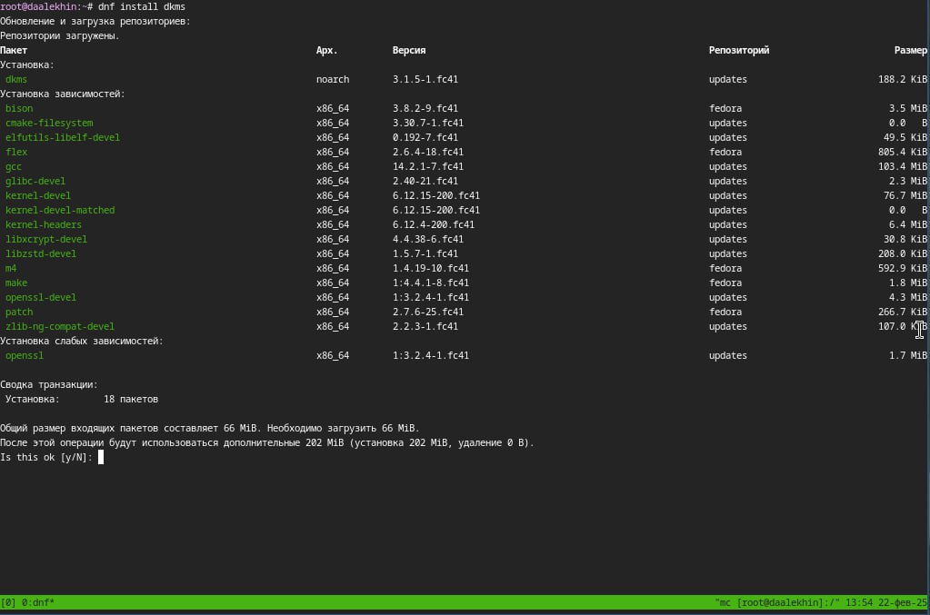

drivers for VirtualBox

## Содержание исследования

[figure not shown]

Selinux

## Содержание исследования

Далее настраиваю раскладку клавиатуры. (рис. [-@fig:004]).

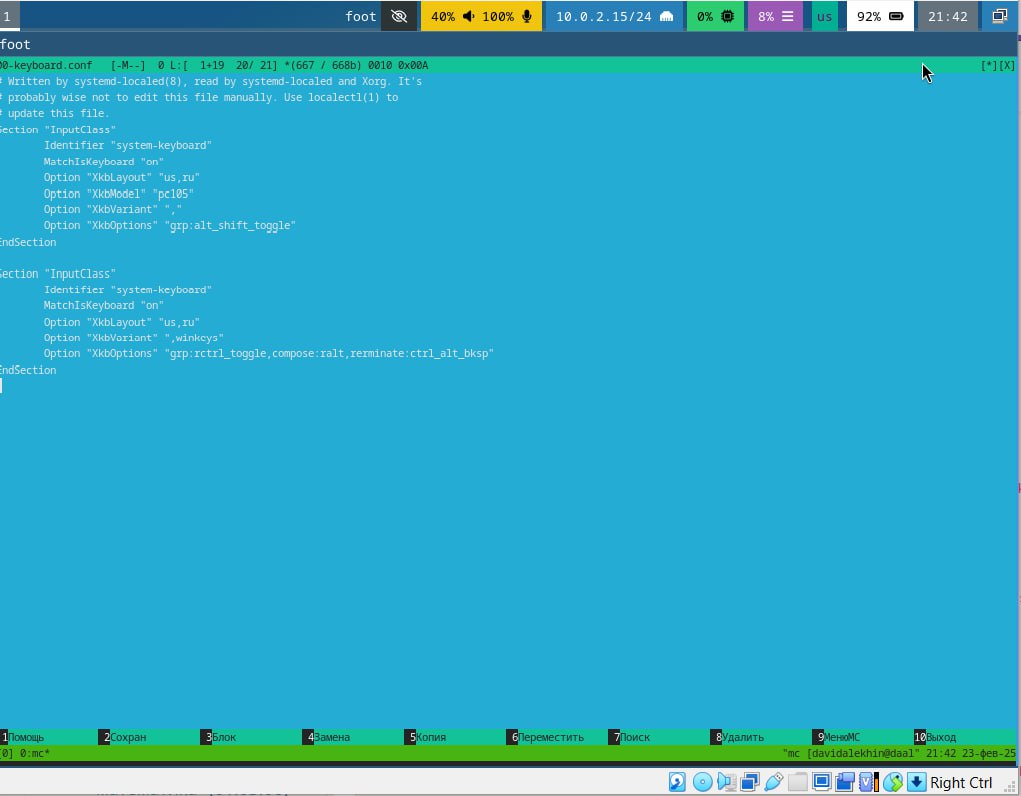

настройка раскладки клавиатуры

## Содержание исследования

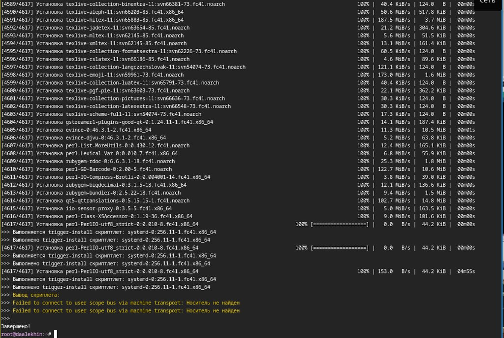

Texlive

## Содержание исследования

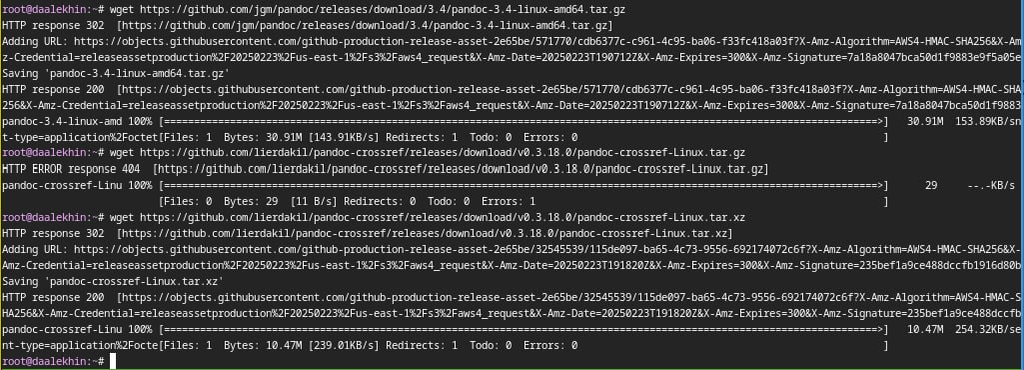

wget Pandoc, Pandoc-crosseref

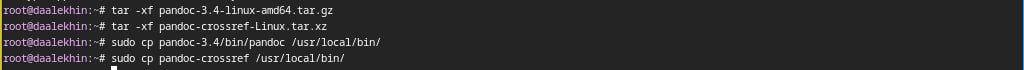

tar,cp

## Содержание исследования

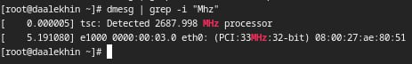

1

## Содержание исследования

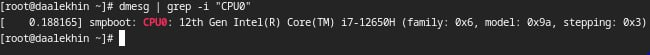

2

## Содержание исследования

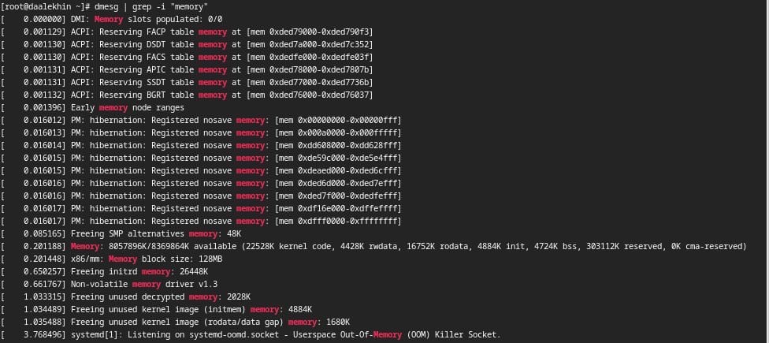

3

## Содержание исследования

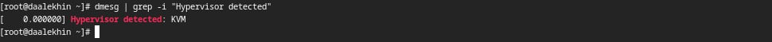

4

## Содержание исследования

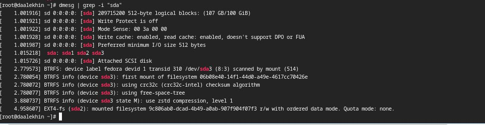

5

## Содержание исследования

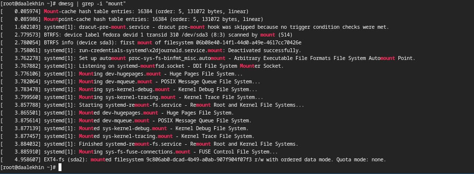

6

## Результаты

В теории, теория и практика неразделимы. На практике это не так. Yoggi Berra